# Insurance Costs

Author

Mehrpad Moattari

Published

November 6, 2023

### Part 1

```python
import pandas as pd

file_path = 'C:/Users/mehrp/OneDrive/Documents/GitHub/Lab_5/insurance_costs_1.csv'

insurance_data = pd.read_csv(file_path)

insurance_data.head()
```

|  | age | sex | bmi | smoker | region | charges |
| --- | --- | --- | --- | --- | --- | --- |
| 0 | 19 | female | 27.900 | yes | southwest | 16884.92400 |
| 1 | 33 | male | 22.705 | no | northwest | 21984.47061 |
| 2 | 32 | male | 28.880 | no | northwest | 3866.85520 |
| 3 | 31 | female | 25.740 | no | southeast | 3756.62160 |
| 4 | 60 | female | 25.840 | no | northwest | 28923.13692 |

```python
summary_description = insurance_data.describe()

#missing values in the dataset
missing_values = insurance_data.isnull().sum()

#Getting a summary of information
info_summary = insurance_data.info()

summary_description, missing_values, info_summary
```

[output not shown]

[output not shown]

#### Fixing the data as needed.

```python
# Convert 'sex', 'smoker', and 'region' to categorical
insurance_data['sex'] = insurance_data['sex'].astype('category')
insurance_data['smoker'] = insurance_data['smoker'].astype('category')
insurance_data['region'] = insurance_data['region'].astype('category')

# Create dummy variables
sex_dummies = pd.get_dummies(insurance_data['sex'], prefix='sex', drop_first=True)
smoker_dummies = pd.get_dummies(insurance_data['smoker'], prefix='smoker', drop_first=True)
region_dummies = pd.get_dummies(insurance_data['region'], prefix='region', drop_first=True)

# Join the dummies back to the main dataframe
insurance_data = pd.concat([insurance_data, sex_dummies, smoker_dummies, region_dummies], axis=1)

# Check the dataframe with new dummy variables
insurance_data.head()
```

[output not shown]

```python
from plotnine import ggplot, aes, geom_point, geom_smooth, labs, theme, element_text
```

##### Age vs. Charges: To see if there’s an increase in charges as age increases, which is typically expected.

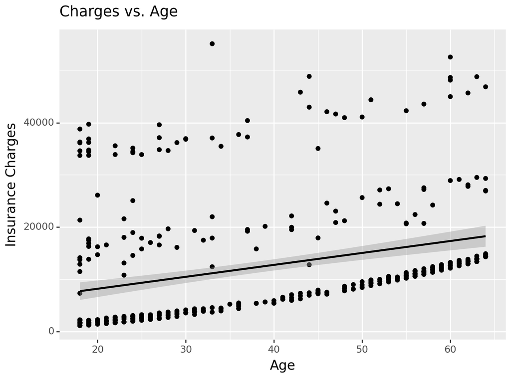

```
<Figure Size: (640 x 480)>
```

```python
plot1 = (ggplot(insurance_data, aes(x='age', y='charges')) +
         geom_point() +
         geom_smooth(method='lm') +  # Adds a linear regression line
         labs(x='Age', y='Insurance Charges', title='Charges vs. Age') +
         theme(axis_title=element_text(size=12)))
plot1
```

##### BMI vs. Charges: To observe if higher BMI is associated with higher charges, as BMI is often related to health risks.

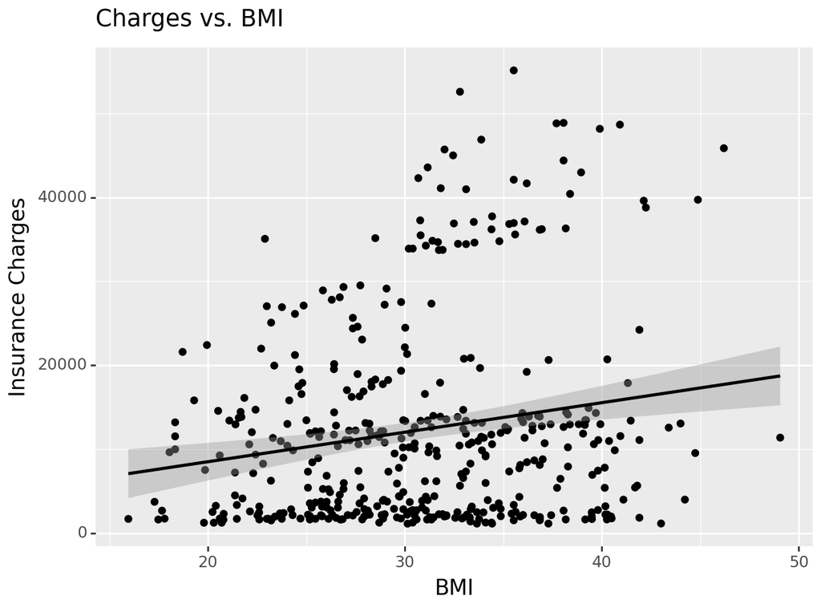

```
<Figure Size: (640 x 480)>
```

```python
plot2 = (ggplot(insurance_data, aes(x='bmi', y='charges')) +
         geom_point() +
         geom_smooth(method='lm') +
         labs(x='BMI', y='Insurance Charges', title='Charges vs. BMI') +
         theme(axis_title=element_text(size=12)))
plot2
```

##### Smoker vs. Charges: To examine the impact of smoking on charges, as it’s known that smoking is a major health risk factor and could lead to higher insurance costs.

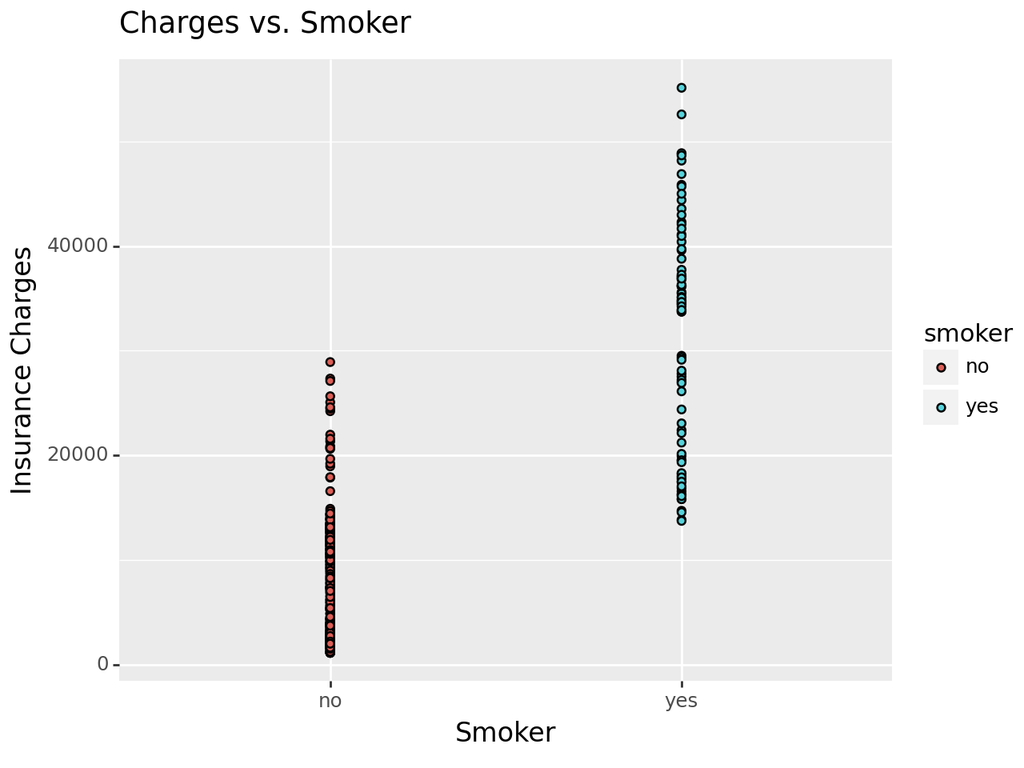

```
<Figure Size: (640 x 480)>
```

```python
plot3 = (ggplot(insurance_data, aes(x='smoker', y='charges', fill='smoker')) +
         geom_point() +
         labs(x='Smoker', y='Insurance Charges', title='Charges vs. Smoker') +
         theme(axis_title=element_text(size=12)))
plot3
```

### Part 2

##### Construct a simple linear model to predict the insurance charges from the beneficiary’s age. Discuss the model fit, and interpret the coefficient estimates.

```python
from sklearn.model_selection import train_test_split
from sklearn.linear_model import LinearRegression
from sklearn.metrics import r2_score, mean_squared_error

# Splitting the features and target
X = insurance_data[['age']]
y = insurance_data['charges']

# Train-test split
X_train, X_test, y_train, y_test = train_test_split(X, y, test_size=0.2, random_state=42)

# Linear Regression model
lr = LinearRegression()

# Train it
lr.fit(X_train, y_train)

# Test predictions
y_pred = lr.predict(X_test)

# Performance metrics
r2 = r2_score(y_test, y_pred)
mse = mean_squared_error(y_test, y_pred)

# Coefficient for age
age_coef = lr.coef_[0]
```

```python
# Print the goodies
print(f'R^2: {r2}')
print(f'MSE: {mse}')
print(f'Age coeff: {age_coef}')
```

```
R^2: 0.1287424190241595
MSE: 141029548.95804176
Age coeff: 214.54607710363027
```

Coefficient for Age (214.546): This number means that, on average, every additional year of age is associated with an increase of approximately $214.55 in insurance charges, all else being equal.

In this case, an R-squared of 0.1287 means that around 12.87% of the variance in insurance charges can be explained by the age of the beneficiary.

A lower MSE indicates a better fit. Given the large MSE in this case, it suggests that there’s a significant variation in the charges that the model doesn’t capture, which is consistent with the low R-squared value.

##### Make a model that also incorporates the variable sex. Report your results. (b)

```python
# Splitting the features and target with 'sex' included
X = insurance_data[['age', 'sex_male']]
y = insurance_data['charges']

# Train-test split
X_train, X_test, y_train, y_test = train_test_split(X, y, test_size=0.2, random_state=42)

# Linear Regression model
lr_sex = LinearRegression()

# Train it
lr_sex.fit(X_train, y_train)

# Test predictions
y_pred_sex = lr_sex.predict(X_test)

# Performance metrics
r2_sex = r2_score(y_test, y_pred_sex)
mse_sex = mean_squared_error(y_test, y_pred_sex)

# Coefficients
age_coef_sex = lr_sex.coef_[0]
sex_coef = lr_sex.coef_[1]
```

```python
# Outputs
print(f'R^2 with sex: {r2_sex}')
print(f'MSE with sex: {mse_sex}')
print(f'Age coeff with sex: {age_coef_sex}')
print(f'Sex coeff: {sex_coef}')
```

```
R^2 with sex: 0.10921970918963841
MSE with sex: 144189669.48097306
Age coeff with sex: 213.45788319254865
Sex coeff: 802.2407791182789
```

##### Now make a model that does not include sex, but does include smoker. Report your results. (c)

```python
# Splitting the features and target with 'smoker' included
X = insurance_data[['age', 'smoker_yes']]
y = insurance_data['charges']

# Train-test split
X_train, X_test, y_train, y_test = train_test_split(X, y, test_size=0.2, random_state=42)

# Linear Regression model
lr_smoker = LinearRegression()

# Train it
lr_smoker.fit(X_train, y_train)

# Test predictions
y_pred_smoker = lr_smoker.predict(X_test)

# Performance metrics
r2_smoker = r2_score(y_test, y_pred_smoker)
mse_smoker = mean_squared_error(y_test, y_pred_smoker)

# Coefficients
age_coef_smoker = lr_smoker.coef_[0]
smoker_coef = lr_smoker.coef_[1]
```

```python
# Outputs
print(f'R^2 with smoker: {r2_smoker}')
print(f'MSE with smoker: {mse_smoker}')
print(f'Age coeff with smoker: {age_coef_smoker}')
print(f'Smoker coeff: {smoker_coef}')
```

```
R^2 with smoker: 0.8316610385322897
MSE with smoker: 27248850.77185306
Age coeff with smoker: 248.83646811654953
Smoker coeff: 11785.265395184091
```

##### Which model (b or c) do you think better fits the data? Justify your answer by calculating the MSE for each model, and also by comparing R-squared values.

##### Model with sex as a predictor

R-squared: 0.1092 (about 10.92% of the variance in charges is explained by the model)

MSE: 144,189,669.48 (the average squared difference between the observed and predicted charges)

##### Model with smoker as a predictor

R-squared: 0.8317 (about 83.17% of the variance in charges is explained by the model)

MSE: MSE: 27,248,850.77 (the average squared difference between the observed and predicted charges)

###### Model c with smoking in the mix nails it way better than model b with just sex. It’s got a killer R-squared of 0.8317, meaning it’s got the story of insurance charges down way better, like 83% better. And the MSE? Way lower, so our predictions are hitting closer to home.Age matters more when you throw smoking into the equation. Makes sense, right? Smokers get hit with way steeper charges (look at that whopping smoker coefficient), and we all know smoking’s no good for you.So yeah, smoking status trumps gender when it comes to predicting those insurance costs. Model c isn’t just good, it’s great, and the numbers back it up.

### Part 3

##### Fit a model that uses age and bmi as predictors. (Do not include an interaction term, age*bmi, between these two.) Report your results. How does the MSE compare to the model in Part Two Q1? How does the R-squared compare?

```python
# Features now include 'bmi'
X = insurance_data[['age', 'bmi']]

# The rest is pretty much the same routine
X_train, X_test, y_train, y_test = train_test_split(X, y, test_size=0.2, random_state=42)

lr_multiple = LinearRegression()
lr_multiple.fit(X_train, y_train)

y_pred_multiple = lr_multiple.predict(X_test)

# New performance metrics
r2_multiple = r2_score(y_test, y_pred_multiple)
mse_multiple = mean_squared_error(y_test, y_pred_multiple)
```

```python
# Now we check out how the new kids on the block did
print(f'R^2 with age and bmi: {r2_multiple}')
print(f'MSE with age and bmi: {mse_multiple}')
```

```
R^2 with age and bmi: 0.1706876553903791
MSE with age and bmi: 134239917.63105714
```

R-squared: 0.1707, which is a step up from our age-only model’s 0.1287. Now we’re explaining about 17.07% of the variance in insurance charges—better, but still a lot left unexplained. MSE: 134,239,917.63, down from 141,029,548.96 with just age. The predictions are getting more accurate; we’re missing the mark by a bit less now. In the grand scheme, adding bmi has given us a bit more clarity.

##### Perhaps the relationships are not linear. Fit a model that uses age and age^2 as predictors. How do the MSE and R-squared compare to the model in P2 Q1?

```python
# Create a new column for age squared
insurance_data['age_squared'] = insurance_data['age'] ** 2

# Features now include 'age' and 'age_squared'
X = insurance_data[['age', 'age_squared']]

# Same splitting routine
X_train, X_test, y_train, y_test = train_test_split(X, y, test_size=0.2, random_state=42)

# Fitting the model
lr_age_squared = LinearRegression()
lr_age_squared.fit(X_train, y_train)

# Making predictions
y_pred_age_squared = lr_age_squared.predict(X_test)

# New performance metrics
r2_age_squared = r2_score(y_test, y_pred_age_squared)
mse_age_squared = mean_squared_error(y_test, y_pred_age_squared)
```

```python
print(f'R^2 with age and age squared: {r2_age_squared}')
print(f'MSE with age and age squared: {mse_age_squared}')
```

```
R^2 with age and age squared: 0.12914290286988972
MSE with age and age squared: 140964723.05883405
```

R-squared: 0.1291 with the age squared model, which is barely a nudge from the 0.1287 with just age. So, it’s like, we’re explaining a tiny bit more variance with the squared term, but it’s not a game-changer. MSE: 140,964,723.06, which is almost the same as the age-only model’s 141,029,548.96. Meaning our prediction error hasn’t really improved much. Bottom line? Squaring the age doesn’t seem to be the magic trick we were hoping for.

##### Fit a polynomial model of degree 4. How do the MSE and R-squared compare to the model in P2 Q1?

```python
from sklearn.preprocessing import PolynomialFeatures

# Generate polynomial features up to degree 4
poly = PolynomialFeatures(degree=4, include_bias=False)
X_poly = poly.fit_transform(insurance_data[['age']])

# Split the data
X_train_poly, X_test_poly, y_train, y_test = train_test_split(X_poly, y, test_size=0.2, random_state=42)

# Fit the model
lr_poly = LinearRegression()
lr_poly.fit(X_train_poly, y_train)

# Make predictions
y_pred_poly = lr_poly.predict(X_test_poly)

# Performance metrics
r2_poly = r2_score(y_test, y_pred_poly)
mse_poly = mean_squared_error(y_test, y_pred_poly)
```

```python
print(f'R^2 with polynomial degree 4: {r2_poly}')
print(f'MSE with polynomial degree 4: {mse_poly}')
```

```
R^2 with polynomial degree 4: 0.14223541742805745
MSE with polynomial degree 4: 138845451.48727775
```

R-squared: 0.1422, a slight uptick from our original model’s R-squared of 0.1287. So we’re doing a bit better at explaining the variance in insurance charges with the more complex model. MSE: 138,845,451.49, which is also a bit better (lower) than the original model’s MSE of 141,029,548.96.So, what’s the story? Tossing in those extra polynomial terms has given us a bit more predictive oomph. We’re not seeing huge leaps, but the model’s definitely getting a better grip on the data compared to the straight-up linear version.

##### Fit a polynomial model of degree 12. How do the MSE and R-squared compare to the model in P2 Q1?

```python
# Generate polynomial features up to degree 12
poly = PolynomialFeatures(degree=12, include_bias=False)
X_poly_12 = poly.fit_transform(insurance_data[['age']])

# Same splitting routine
X_train_poly_12, X_test_poly_12, y_train, y_test = train_test_split(X_poly_12, y, test_size=0.2, random_state=42)

# Fit the model
lr_poly_12 = LinearRegression()
lr_poly_12.fit(X_train_poly_12, y_train)

# Make predictions
y_pred_poly_12 = lr_poly_12.predict(X_test_poly_12)

# Performance metrics
r2_poly_12 = r2_score(y_test, y_pred_poly_12)
mse_poly_12 = mean_squared_error(y_test, y_pred_poly_12)
```

```python
print(f'R^2 with polynomial degree 12: {r2_poly_12}')
print(f'MSE with polynomial degree 12: {mse_poly_12}')
```

```
R^2 with polynomial degree 12: 0.12391950693205567
MSE with polynomial degree 12: 141810228.66960523
```

R-squared: 0.1239, which is actually a bit lower than the 0.1287 R-squared for the simple linear model. So, in terms of explaining the variance in the data, this more complex model isn’t doing as well as the simpler ones.MSE: 141,810,228.67, which is slightly higher than the 141,029,548.96 MSE for the linear model. This means that the degree 12 model’s predictions are on average less accurate than the simpler model’s predictions.In the real talk? This is classic overfitting territory.

##### Plot the predictions from your model in Q4 as a line plot on top of the scatterplot of your original data.

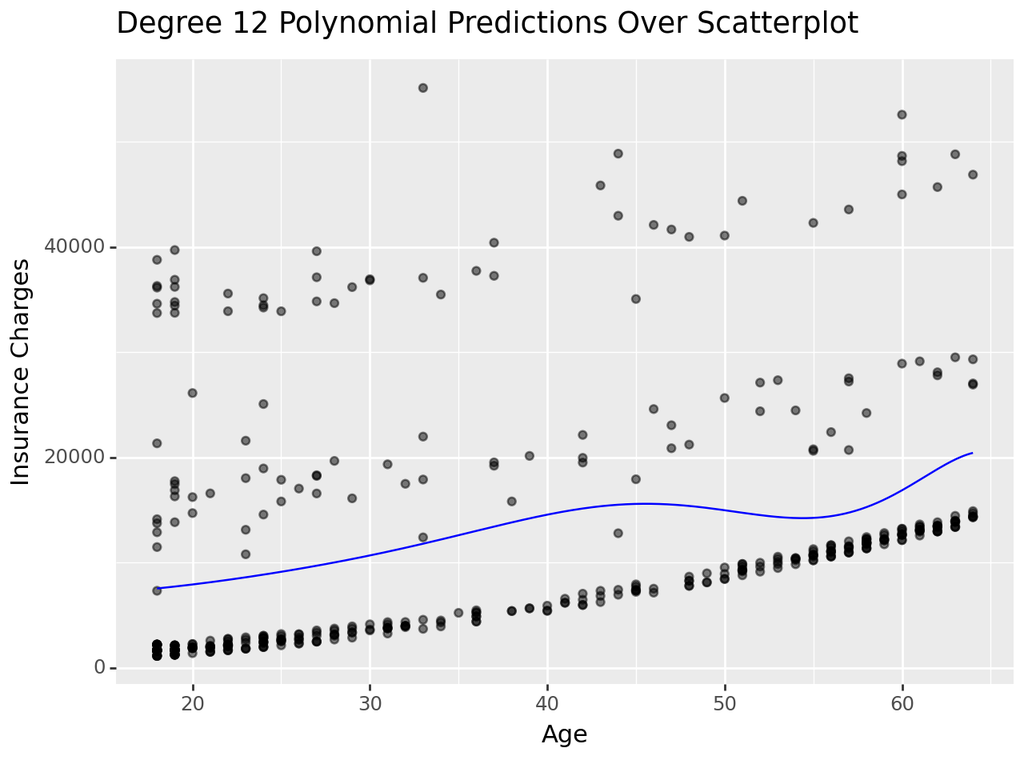

```python
import numpy as np
from plotnine import ggplot, aes, geom_point, geom_line, xlab, ylab, ggtitle

# Create a DataFrame for the predictions
predictions_df = pd.DataFrame({
    'age': age_range,
    'predictions': predictions
})

# Plot the original data and the prediction line
plot = (
    ggplot(insurance_data, aes(x='age', y='charges')) +
    geom_point(alpha=0.5) +
    geom_line(predictions_df, aes(x='age', y='predictions'), color='blue') +
    xlab("Age") +
    ylab("Insurance Charges") +
    ggtitle("Degree 12 Polynomial Predictions Over Scatterplot")
)

print(plot)
```

### Part 4

##### For each model, fit the model on the original data.

```python
file_path_new = 'C:/Users/mehrp/OneDrive/Documents/GitHub/Lab_5/insurance_costs_2.csv'
new_insurance_data = pd.read_csv(file_path_new)

new_insurance_data.head()
```

|  | age | sex | bmi | smoker | region | charges |
| --- | --- | --- | --- | --- | --- | --- |
| 0 | 23 | male | 34.400 | no | southwest | 1826.84300 |
| 1 | 56 | male | 40.300 | no | southwest | 10602.38500 |
| 2 | 18 | male | 34.100 | no | southeast | 1137.01100 |
| 3 | 63 | female | 23.085 | no | northeast | 14451.83515 |
| 4 | 63 | male | 28.310 | no | northwest | 13770.09790 |

```python
# Convert 'sex', 'smoker', and 'region' to categorical variables
new_insurance_data['sex'] = new_insurance_data['sex'].astype('category')
new_insurance_data['smoker'] = new_insurance_data['smoker'].astype('category')
new_insurance_data['region'] = new_insurance_data['region'].astype('category')

# Create dummy variables for 'sex', 'smoker', and 'region' for the new data
sex_dummies_new = pd.get_dummies(new_insurance_data['sex'], prefix='sex', drop_first=True)
smoker_dummies_new = pd.get_dummies(new_insurance_data['smoker'], prefix='smoker', drop_first=True)
region_dummies_new = pd.get_dummies(new_insurance_data['region'], prefix='region', drop_first=True)

# Join the dummies back to the main dataframe
new_insurance_data_clean = pd.concat([new_insurance_data, sex_dummies_new, smoker_dummies_new, region_dummies_new], axis=1)

new_insurance_data_clean.head()
```

|  | age | sex | bmi | smoker | region | charges | sex_male | smoker_yes | region_northwest | region_southeast | region_southwest |
| --- | --- | --- | --- | --- | --- | --- | --- | --- | --- | --- | --- |
| 0 | 23 | male | 34.400 | no | southwest | 1826.84300 | True | False | False | False | True |
| 1 | 56 | male | 40.300 | no | southwest | 10602.38500 | True | False | False | False | True |
| 2 | 18 | male | 34.100 | no | southeast | 1137.01100 | True | False | False | True | False |
| 3 | 63 | female | 23.085 | no | northeast | 14451.83515 | False | False | False | False | False |
| 4 | 63 | male | 28.310 | no | northwest | 13770.09790 | True | False | True | False | False |

```python
# Re-load the original dataset
file_path_original = 'C:/Users/mehrp/OneDrive/Documents/GitHub/Lab_5/insurance_costs_1.csv'
original_insurance_data = pd.read_csv(file_path_original)

# Convert 'sex', 'smoker', and 'region' for the OG
original_insurance_data['sex'] = original_insurance_data['sex'].astype('category')
original_insurance_data['smoker'] = original_insurance_data['smoker'].astype('category')
original_insurance_data['region'] = original_insurance_data['region'].astype('category')

#'sex', 'smoker', and 'region' for the OG
sex_dummies_original = pd.get_dummies(original_insurance_data['sex'], prefix='sex', drop_first=True)
smoker_dummies_original = pd.get_dummies(original_insurance_data['smoker'], prefix='smoker', drop_first=True)
region_dummies_original = pd.get_dummies(original_insurance_data['region'], prefix='region', drop_first=True)


original_insurance_data_clean = pd.concat([original_insurance_data, sex_dummies_original, smoker_dummies_original, region_dummies_original], axis=1)


original_insurance_data_clean.head()
```

|  | age | sex | bmi | smoker | region | charges | sex_male | smoker_yes | region_northwest | region_southeast | region_southwest |
| --- | --- | --- | --- | --- | --- | --- | --- | --- | --- | --- | --- |
| 0 | 19 | female | 27.900 | yes | southwest | 16884.92400 | False | True | False | False | True |
| 1 | 33 | male | 22.705 | no | northwest | 21984.47061 | True | False | True | False | False |
| 2 | 32 | male | 28.880 | no | northwest | 3866.85520 | True | False | True | False | False |
| 3 | 31 | female | 25.740 | no | southeast | 3756.62160 | False | False | False | True | False |
| 4 | 60 | female | 25.840 | no | northwest | 28923.13692 | False | False | True | False | False |

```python
# Initialize the linear regression model
lm = LinearRegression()

# Model 1: Only age as a predictor
X1 = original_insurance_data_clean[['age']]
y = original_insurance_data_clean['charges']
lm.fit(X1, y)
r2_age = lm.score(X1, y)

# Model 2: Age and BMI as predictors
X2 = original_insurance_data_clean[['age', 'bmi']]
lm.fit(X2, y)
r2_age_bmi = lm.score(X2, y)

# Model 3: Age, BMI, and smoker as predictors (no interaction terms)
X3 = original_insurance_data_clean[['age', 'bmi', 'smoker_yes']]
lm.fit(X3, y)
r2_age_bmi_smoker = lm.score(X3, y)

# For models with interaction terms, we need to create those terms
original_insurance_data_clean['age_smoker'] = original_insurance_data_clean['age'] * original_insurance_data_clean['smoker_yes']
original_insurance_data_clean['bmi_smoker'] = original_insurance_data_clean['bmi'] * original_insurance_data_clean['smoker_yes']

# Model 4: Age and BMI, with interaction terms with smoker
X4 = original_insurance_data_clean[['age', 'bmi', 'smoker_yes', 'age_smoker', 'bmi_smoker']]
lm.fit(X4, y)
r2_age_bmi_int_smoker = lm.score(X4, y)

# Model 5: Age, BMI, and smoker as predictors, with interaction terms with smoker
X5 = original_insurance_data_clean[['age', 'bmi', 'smoker_yes', 'age_smoker', 'bmi_smoker']]
lm.fit(X5, y)
r2_age_bmi_smoker_int = lm.score(X5, y)

# Compile the results
results = {
    'Model 1: Only Age': r2_age,
    'Model 2: Age and BMI': r2_age_bmi,
    'Model 3: Age, BMI, Smoker': r2_age_bmi_smoker,
    'Model 4: Age, BMI, Interaction with Smoker': r2_age_bmi_int_smoker,
    'Model 5: Age, BMI, Smoker, Interaction with Smoker': r2_age_bmi_smoker_int
}

results
```

```
{'Model 1: Only Age': 0.09938105452062707,
 'Model 2: Age and BMI': 0.12032144234129338,
 'Model 3: Age, BMI, Smoker': 0.7810467724680946,
 'Model 4: Age, BMI, Interaction with Smoker': 0.8672991020173331,
 'Model 5: Age, BMI, Smoker, Interaction with Smoker': 0.8672991020173331}
```

```python
# First, the new data like the original with the interaction terms
new_insurance_data_clean['age_smoker'] = new_insurance_data_clean['age'] * new_insurance_data_clean['smoker_yes']
new_insurance_data_clean['bmi_smoker'] = new_insurance_data_clean['bmi'] * new_insurance_data_clean['smoker_yes']

# New data for predictions
X1_new = new_insurance_data_clean[['age']]
X2_new = new_insurance_data_clean[['age', 'bmi']]
X3_new = new_insurance_data_clean[['age', 'bmi', 'smoker_yes']]
X4_new = new_insurance_data_clean[['age', 'bmi', 'smoker_yes', 'age_smoker', 'bmi_smoker']]
X5_new = new_insurance_data_clean[['age', 'bmi', 'smoker_yes', 'age_smoker', 'bmi_smoker']]
y_new = new_insurance_data_clean['charges']

# Predict on the new data
y_pred_1 = lm.fit(X1, y).predict(X1_new)
y_pred_2 = lm.fit(X2, y).predict(X2_new)
y_pred_3 = lm.fit(X3, y).predict(X3_new)
y_pred_4 = lm.fit(X4, y).predict(X4_new)
y_pred_5 = lm.fit(X5, y).predict(X5_new)

# Calculate MSE for the predictions
mse_1 = mean_squared_error(y_new, y_pred_1)
mse_2 = mean_squared_error(y_new, y_pred_2)
mse_3 = mean_squared_error(y_new, y_pred_3)
mse_4 = mean_squared_error(y_new, y_pred_4)
mse_5 = mean_squared_error(y_new, y_pred_5)

# Compile the MSE results
mse_results = {
    'Model 1: Only Age': mse_1,
    'Model 2: Age and BMI': mse_2,
    'Model 3: Age, BMI, Smoker': mse_3,
    'Model 4: Age, BMI, Interaction with Smoker': mse_4,
    'Model 5: Age, BMI, Smoker, Interaction with Smoker': mse_5
}

mse_results
```

```
{'Model 1: Only Age': 136077136.50195494,
 'Model 2: Age and BMI': 132636406.1108129,
 'Model 3: Age, BMI, Smoker': 35377541.24141632,
 'Model 4: Age, BMI, Interaction with Smoker': 21786256.866852645,
 'Model 5: Age, BMI, Smoker, Interaction with Smoker': 21786256.866852645}
```

Based on the MSE, the best models are Model 4 and Model 5, which have the exact same performance in terms of MSE. These models include interaction terms between age and smoker, and BMI and smoker, indicating that these interactions are significant in predicting insurance costs.

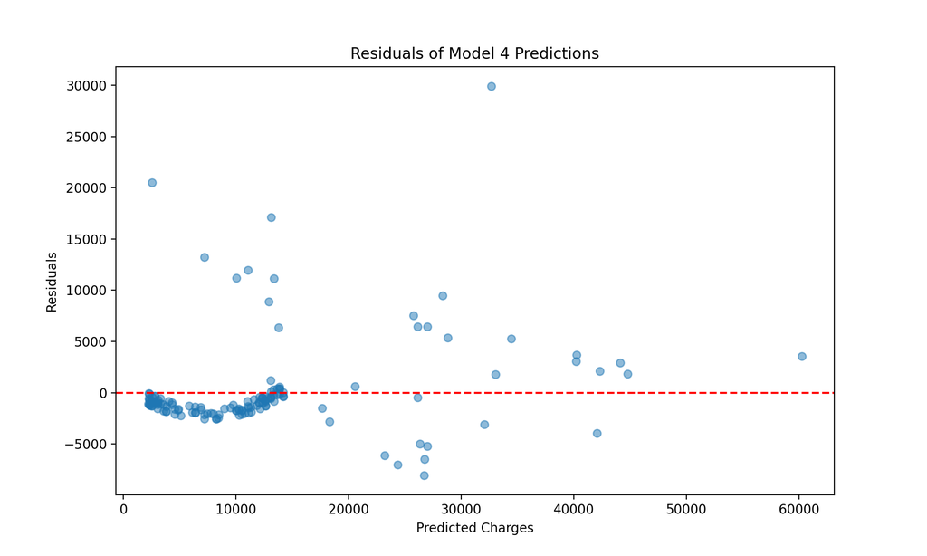

```python
import matplotlib.pyplot as plt

# Calculate residuals for Model 4
residuals = y_new - y_pred_4

# Plotting the residuals
plt.figure(figsize=(10, 6))
plt.scatter(y_pred_4, residuals, alpha=0.5)
plt.title('Residuals of Model 4 Predictions')
plt.xlabel('Predicted Charges')
plt.ylabel('Residuals')
plt.axhline(y=0, color='r', linestyle='--')
plt.show()
```

### Part 5

#### Got a bit confused here, so I decided to restructure things a bit.

```python
# OG data
original_file_path = 'C:/Users/mehrp/OneDrive/Documents/GitHub/Lab_5/insurance_costs_1.csv'
insurance_data_original = pd.read_csv(original_file_path)

# New Data
new_file_path = 'C:/Users/mehrp/OneDrive/Documents/GitHub/Lab_5/insurance_costs_2.csv'
insurance_data_new = pd.read_csv(new_file_path)

# OG Data, Convert 'sex', 'smoker', 'region' to categorical and dummy variables
insurance_data_original['sex'] = insurance_data_original['sex'].astype('category')
insurance_data_original['smoker'] = insurance_data_original['smoker'].astype('category')
insurance_data_original['region'] = insurance_data_original['region'].astype('category')

sex_dummies = pd.get_dummies(insurance_data_original['sex'], prefix='sex', drop_first=True)
smoker_dummies = pd.get_dummies(insurance_data_original['smoker'], prefix='smoker', drop_first=True)
region_dummies = pd.get_dummies(insurance_data_original['region'], prefix='region', drop_first=True)
insurance_data_original = pd.concat([insurance_data_original, sex_dummies, smoker_dummies, region_dummies], axis=1)

# New data, same way
insurance_data_new['sex'] = insurance_data_new['sex'].astype('category')
insurance_data_new['smoker'] = insurance_data_new['smoker'].astype('category')
insurance_data_new['region'] = insurance_data_new['region'].astype('category')

sex_dummies_new = pd.get_dummies(insurance_data_new['sex'], prefix='sex', drop_first=True)
smoker_dummies_new = pd.get_dummies(insurance_data_new['smoker'], prefix='smoker', drop_first=True)
region_dummies_new = pd.get_dummies(insurance_data_new['region'], prefix='region', drop_first=True)
insurance_data_new = pd.concat([insurance_data_new, sex_dummies_new, smoker_dummies_new, region_dummies_new], axis=1)

# both datasets have the same dummy columns
for column in set(insurance_data_original.columns) - set(insurance_data_new.columns):
    insurance_data_new[column] = 0

for column in set(insurance_data_new.columns) - set(insurance_data_original.columns):
    insurance_data_original[column] = 0

# Fit the first model: Only age as a predictor
X_original = insurance_data_original[['age']]
y_original = insurance_data_original['charges']

lr_age = LinearRegression()
lr_age.fit(X_original, y_original)

# Predict on the new data
X_new = insurance_data_new[['age']]
y_new = insurance_data_new['charges']
y_pred_age = lr_age.predict(X_new)

# Calculate MSE for the age model predictions
mse_age = mean_squared_error(y_new, y_pred_age)

# Output the MSE for the first model
mse_age
```

```
136077136.50195494
```

For above ^ Fitted a model with just age as a predictor on the original data.

Predicted charges on the new data.

Calculated the MSE for these predictions and it’s around 136,077,136.50.

```python
# Fit the second model: age and bmi as predictors
X_original = insurance_data_original[['age', 'bmi']]
y_original = insurance_data_original['charges']

lr_age_bmi = LinearRegression()
lr_age_bmi.fit(X_original, y_original)

# Predict on the new data
X_new = insurance_data_new[['age', 'bmi']]
y_pred_age_bmi = lr_age_bmi.predict(X_new)

# Calculate MSE for the age and bmi model predictions
mse_age_bmi = mean_squared_error(y_new, y_pred_age_bmi)

# Fit the third model: age, bmi, and smoker as predictors (no interaction terms)
X_original = insurance_data_original[['age', 'bmi', 'smoker_yes']]
lr_age_bmi_smoker = LinearRegression()
lr_age_bmi_smoker.fit(X_original, y_original)

# Predict on the new data
X_new = insurance_data_new[['age', 'bmi', 'smoker_yes']]
y_pred_age_bmi_smoker = lr_age_bmi_smoker.predict(X_new)

# Calculate MSE for the age, bmi, and smoker model predictions
mse_age_bmi_smoker = mean_squared_error(y_new, y_pred_age_bmi_smoker)

# Fit the fourth model: age, bmi, and smoker as predictors, with interaction terms
# the interaction terms manually
insurance_data_original['age_smoker'] = insurance_data_original['age'] * insurance_data_original['smoker_yes']
insurance_data_original['bmi_smoker'] = insurance_data_original['bmi'] * insurance_data_original['smoker_yes']

insurance_data_new['age_smoker'] = insurance_data_new['age'] * insurance_data_new['smoker_yes']
insurance_data_new['bmi_smoker'] = insurance_data_new['bmi'] * insurance_data_new['smoker_yes']

X_original = insurance_data_original[['age', 'bmi', 'smoker_yes', 'age_smoker', 'bmi_smoker']]
lr_interaction = LinearRegression()
lr_interaction.fit(X_original, y_original)

# Predict on the new data
X_new = insurance_data_new[['age', 'bmi', 'smoker_yes', 'age_smoker', 'bmi_smoker']]
y_pred_interaction = lr_interaction.predict(X_new)

# Calculate MSE for the interaction model predictions
mse_interaction = mean_squared_error(y_new, y_pred_interaction)

# Now, let's compare the MSEs
(mse_age, mse_age_bmi, mse_age_bmi_smoker, mse_interaction)
```

```
(136077136.50195494, 132636406.1108129, 35377541.24141632, 21786256.866852645)
```

Just age: 136,077,136.50

Age and BMI: 132,636,406.11

Age, BMI, and smoker (no interactions): 35,377,541.24

Age, BMI, and smoker (with interactions): 21,786,256.87

The last one, with the interaction terms, is killing it with the lowest MSE

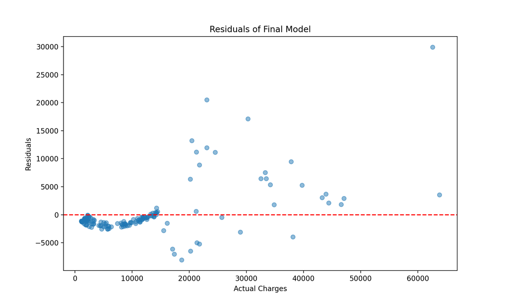

```python
residuals = y_new - y_pred_interaction

# Plotting residuals
plt.figure(figsize=(10,6))
plt.scatter(y_new, residuals, alpha=0.5)
plt.title('Residuals of Final Model')
plt.xlabel('Actual Charges')
plt.ylabel('Residuals')
plt.axhline(y=0, color='r', linestyle='--')
plt.show()
```